# Manual for the Stochastic Production model in Continuous Time (SPiCT)

#### 2.11.2.4 Advanced management settings and functionality

Besides selecting scenarios in `manage` using the argument `scenarios`, the function `man.select` can be used to change the order of scenarios or omit certain or all scenarios included in `rep$man`:

```r
names(rep$man)
   [1] "currentCatch"   "currentF"       "Fmsy"           "noF"
   [5] "reduceF25"      "increaseF25"    "msyHockeyStick" "ices"
rep <- man.select(rep, scenarios = c(1,3))
   Selected scenario(s):  currentCatch, Fmsy
```

One of the important quantities in fisheries management is the predicted catch during the management interval under given fishing mortality, also called Total Allowable Catch (TAC). The function `man.tac` allows to extract a list with the TAC of all scenarios in `rep$man`:

```r
man.tac(rep)
   $currentCatch
   [1] 25.22001

   $Fmsy
   [1] 21.25489
```

Note that the unit of the TAC corresponds to the catch unit specified in `inp$catchunit` or the unit of the catch observations if not specified. If the user is only interested in the TAC of the specified management scenario (e.f. for the implementation in a management strategy framework (MSE)), the function `get.TAC` can be used:

```r
get.TAC(rep, maninterval = c(1990.25, 1991),
        safeguardB = list(limitB = 0.3), verbose = TRUE)
   Note that the specified management interval: 1990.25 - 1991.00 differs from existing scenarios in rep$man.
   [1] 15.73704
```

After comparing the implications of different management scenarios, it might of interest to extract an individual scenario for further analyses, plotting, or reporting. Individual scenarios can be extracted from the SPiCT object by referencing their names or positioning in the list `rep$man`. The extracted object is a standard SPiCT object of the class `spictcls`, which allows for example to plot trajectories and uncertainties of predicted quantities by:

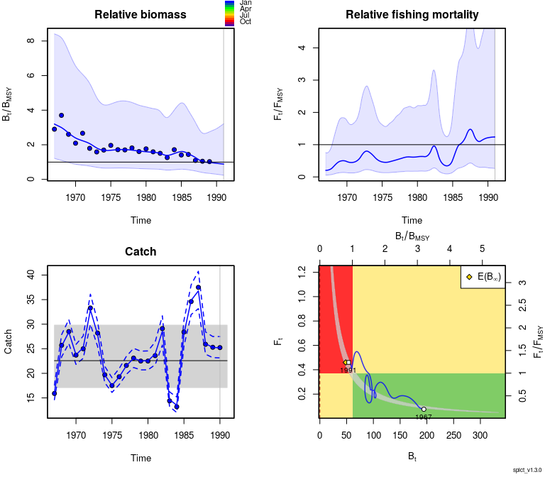

```r
## with index
rep_scenario2 <- rep$man[[2]]
## with scenario name
names(rep$man)
   [1] "currentCatch" "Fmsy"
rep_cc <- rep$man$currentCatch
## plotted as standard spict object
plot2(rep_cc)
```

All management related results can easily be removed from the SPiCT object by overwriting the `man` element: `rep$man = NULL` or

```r
rep <- man.select(rep, scenarios = NULL)
   All scenarios removed!
```

# 3 Other model settings and options

## 3.1 `catchunit` - Define unit of catch observations

This will print the unit of the catches on relevant plots.

Example: `inp$catchunit <- "'000 t"`.

## 3.2 `dteuler` and `eulertype` - Temporal discretisation and time step

To solve the continuous-time system an Euler discretisation scheme is used. This requires a time step to be specified (`dteuler`). The smaller the time step the more accurate the approximation to the continuous-time solution, however with the cost of increased memory requirements and computing time. The default value of `dteuler` is $1/16$, which seems sufficiently fine for most cases, and perhaps too fine for some cases. When fitting quarterly data and species with fast growth it is important to have a small `dteuler`. The influence of `dteuler` on the results can be checked by using different values and comparing resulting model estimates. If `dteuler <- 1` the model essentially becomes a discrete-time model with one Euler step per year.

There are two possible temporal discretisation schemes which can be set to either `eulertype = 'hard'` (default) or `eulertype = 'soft'`. If `eulertype = 'hard'` then time is discretised into intervals of length `dteuler`. Observations are then assigned to these intervals. For annual and quarterly data `dteuler = 1/16` is appropriate, however if fitting to monthly data `dteuler` should be changed to e.g. `1/24`. If `eulertype = 'soft'` (careful, this feature has not been thoroughly tested), then time is discretised into intervals of length `dteuler` and additional time points corresponding to the times of observation are added to the discretisation. This feature is particularly useful if observations (most likely index series) are observed at odd times during the year. The model then estimates values of biomass and fishing mortality at the exact time of the observation instead of assigning the observation to an interval.

## 3.3 `msytype` - Stochastic and deterministic reference points

As default the stochastic reference points are reported and used for calculation of relative levels of biomass and fishing mortality. It is, however, possible to use the deterministic reference points by setting `inp$msytype <- 'd'`.

## 3.4 `do.sd.report` - Perform SD report calculations

The sdreport step calculates the uncertainty of all quantities that are reported in addition to the model parameters. For long time series and with small `dteuler` this step may have high memory requirements and a substantial computing time. Thus, if one is only interested in the point estimates of the model parameters it is advisable to set `do.sd.report <- 0` to increase speed.

## 3.5 `reportall` - Report all derived quantities

If uncertainties of some quantities (such as reference points) are required, but uncertainty on state variables (biomass and fishing mortality) are not needed, then `reportall <- 0` can be used to increase speed.

Parameter estimation is per default performed using R’s `nlminb()` optimiser. Alternatively it is possible to use `optim` by setting `inp$optim.method <- 'optim'`.

# References

ICES. 2019. “Ninth Workshop on the Development of Quantitative Assessment Methodologies based on LIFE-history traits, exploitation characteristics, and other relevant parameters for data-limited stocks (WKLIFE IX).” *ICES Scientific Reports* 1 (77): 131 pp. https://doi.org/10.17895/ices.pub.5550.

Pedersen, Martin W., and Casper W. Berg. 2017. “A stochastic surplus production model in continuous time.” *Fish and Fisheries* 18 (2): 226–43. https://doi.org/10.1111/faf.12174.

Polacheck, Tom, Ray Hilborn, and Andre E Punt. 1993. “Fitting Surplus Production Models: Comparing Methods and Measuring Uncertainty.” *Canadian Journal of Fisheries and Aquatic Sciences* 50 (12): 2597–2607.